# Exploração da correlação do clima em João Pessoa, Campina Grande e Patos - PB

```r
library(tidyverse)
library(here)
library(gridExtra)
```

```r
# SEMPRE read_csv NUNCA read.csv
clima_tudo = read_csv(
    here("data/tempo-jp-cg-pt.csv"),
    col_types = cols(
        .default = col_double(),
        cidade = col_character(),
        semana = col_date(format = ""),
        ano = col_integer(),
        mes = col_integer()
    )
)
```

### Descrição da relação entre a temperatura de uma semana e a temperatura da semana passada nas 3 cidades.

*Para a descrição da relação das temperaturas, foram usados todos os dados sobre temperatura média semanal dos dados originais.*

```r
clima = clima_tudo %>%
  mutate(temp_anterior = lag(temp_media, n = 1))

temperatura_semanal = clima %>%
    filter(!is.na(temp_anterior)) %>%
    filter(!is.na(temp_media)) %>%
    select(temp_media, temp_anterior, semana, cidade)
```

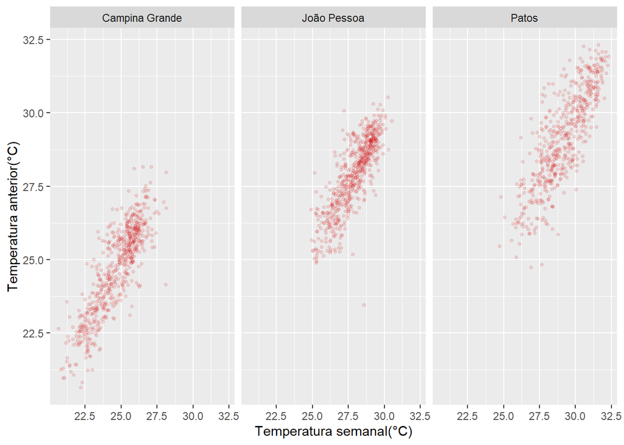

```r
temperatura_semanal %>%
    ggplot(aes(x = temp_media, y = temp_anterior)) +
    facet_wrap(~ cidade) +
    geom_point(alpha = .12, size = 1, colour="red3") +
    labs(
        x = "Temperatura semanal(°C)",
        y = "Temperatura anterior(°C)"
    )
```

**Observa-se que, de modo geral, a correlação da temperatura semanal com a temperatura da semana anterior das cidades apresenta um formato linear com sinal positivo, com a presença de poucos pontos extremos. As três cidades apresentam gráficos de dispersão com formatos semelhantes, com apenas Patos apresentando uma dispersão um pouco maior dos dados.**

```r
temperatura_semanal %>%
    group_by(cidade) %>%
    summarise(correlacao = cor(temp_media, temp_anterior,
                                 method = "pearson"),
              .groups = "drop")
```

```
## # A tibble: 3 x 2
##   cidade         correlacao
##   <chr>               <dbl>
## 1 Campina Grande      0.859
## 2 João Pessoa         0.820
## 3 Patos               0.819
```

**Com a análise do coeficiente de correlação de Pearson, é possível notar que de fato, existe um grau de relacionamento consideravelmente forte entre as temperaturas das semanas analisadas com as temperaturas das semanas anteriores, com Campina Grande apresentando uma intensidade de correlação mais forte entre as três cidades, enquanto Patos e João Pessoa possuem correlações semelhantes.**

### Descrição da relação entre temperatura e chuvas nas semanas em que choveu nas 3 cidades.

```r
temperatura_chuva = clima_tudo %>%
    filter(chuva > 0) %>%
    filter(!is.na(temp_media)) %>%
    select(temp_media, chuva, cidade, semana)
```

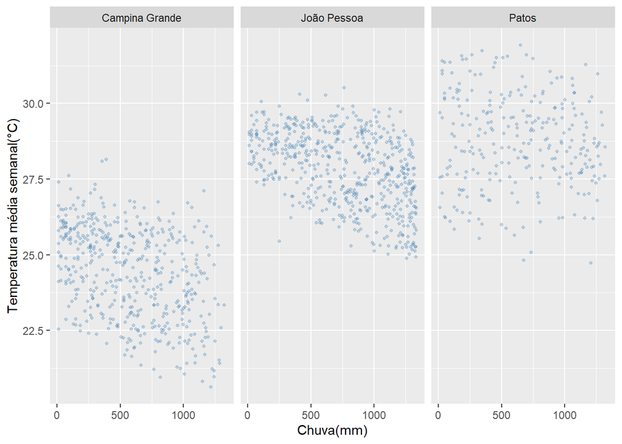

```r
temperatura_chuva %>%
    mutate(log_chuva = log10(chuva)) %>%
    mutate(chuva = rank(log_chuva)) %>%
    ggplot(aes(x = chuva, y = temp_media)) +
    facet_wrap(~ cidade) +
    geom_point(alpha = .3, size = 0.9, colour="steelblue") +
    labs(
        x = "Chuva(mm)",
        y = "Temperatura média semanal(°C)"
    )
```

**É possível observar que o formato dos dados assume algo parecido com o padrão linear com sinal negativo nas cidades de Campina Grande e João Pessoa com alguns pontos extremos, porém em Patos este padrão não pode ser observado. Os gráficos indicam que existe uma fraca correlação entre a chuva e a temperatura nas cidades observadas.**

```r
temperatura_chuva %>%
   mutate(log_chuva = log10(chuva)) %>%
   mutate(chuva_rank = rank(log_chuva)) %>%
   group_by(cidade) %>%
   summarise(pearson_transformado = cor(temp_media, chuva_rank,
                                        method = "pearson"),
             spearman = cor(temp_media, chuva, method = "spearman"),
              .groups = "drop")
```

```
## # A tibble: 3 x 3
##   cidade         pearson_transformado spearman
##   <chr>                         <dbl>    <dbl>
## 1 Campina Grande              -0.411   -0.401
## 2 João Pessoa                 -0.442   -0.436
## 3 Patos                       -0.0876  -0.0882
```

**Com a análise do coeficiente de correlação de Spearman, é possível observar que de fato, existe uma baixa intensidade na correlação entre chuva e temperatura das três cidades, muito similar quando comparada a correlação de Pearson. Nota-se também que a correlação mais baixa entre temperatura e chuva é em Patos. Com isso, pode-se concluir que existe pouca correlação entre a chuva e a temperatura nas semanas em que houve ocorrência de chuva em Campina Grande, João Pessoa e Patos.**

```r
clima = clima_tudo %>%
  mutate(temp_anterior = lag(temp_media, n = 1))

temp_semanal1 = clima %>%
    filter(!is.na(temp_anterior)) %>%
    filter(!is.na(temp_media)) %>%
    filter(semana >= "2019-11-10" & semana <= "2019-12-31" ) %>%
    select(temp_media, temp_anterior, semana, cidade)
```

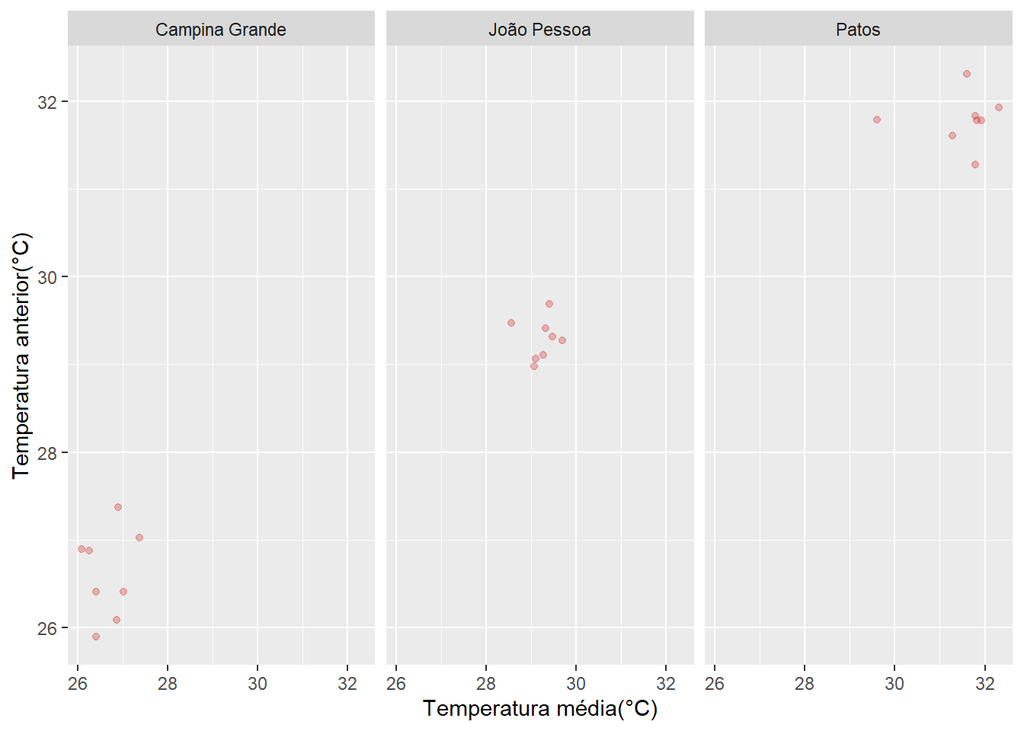

```r
temp_semanal1 %>%
    ggplot(aes(x = temp_media, y = temp_anterior)) +
    geom_point(alpha = .25, size = 1.5, colour="red3") +
    facet_wrap(~ cidade) +
    labs(
        x = "Temperatura média(°C)",
        y = "Temperatura anterior(°C)"
    )
```

**Avaliando apenas relação da temperatura de uma semana com as 8 outras que a antecedem, não é possível determinar um padrão linear nem seu sinal, diferentemente da primeira avaliação da relação das temperaturas.**

```r
temp_semanal1 %>%
   group_by(cidade) %>%
   summarise(correlacao = cor(temp_media, temp_anterior,
                              method = "pearson"),
              .groups = "drop")
```

```
## # A tibble: 3 x 2
##   cidade         correlacao
##   <chr>               <dbl>
## 1 Campina Grande     0.164
## 2 João Pessoa        0.0486
## 3 Patos              0.0353
```

**Ao analisar o coeficiente de Pearson das temperaturas coletadas, percebe-se que existe uma correlação com o grau de intensidade muito baixo entre elas, com valores bem próximos de zero, com a mais alta sendo apenas Campina Grande. Porém, estes dados provavelmente não são o suficiente para determinar se existe correlação visto que é um conjunto muito pequeno.**

*Para a análise de 1 ano foi escolhida a última semana de dezembro e as que a antecederam, até a última semana de dezembro de 2018.*

```r
clima = clima_tudo %>%
  mutate(temp_anterior = lag(temp_media, n = 1))

temp_semanal2 = clima %>%
    filter(!is.na(temp_anterior)) %>%
    filter(!is.na(temp_media)) %>%
    filter(semana >= "2018-12-31" & semana <= "2019-12-31" ) %>%
    select(temp_media, temp_anterior, semana, cidade)
```

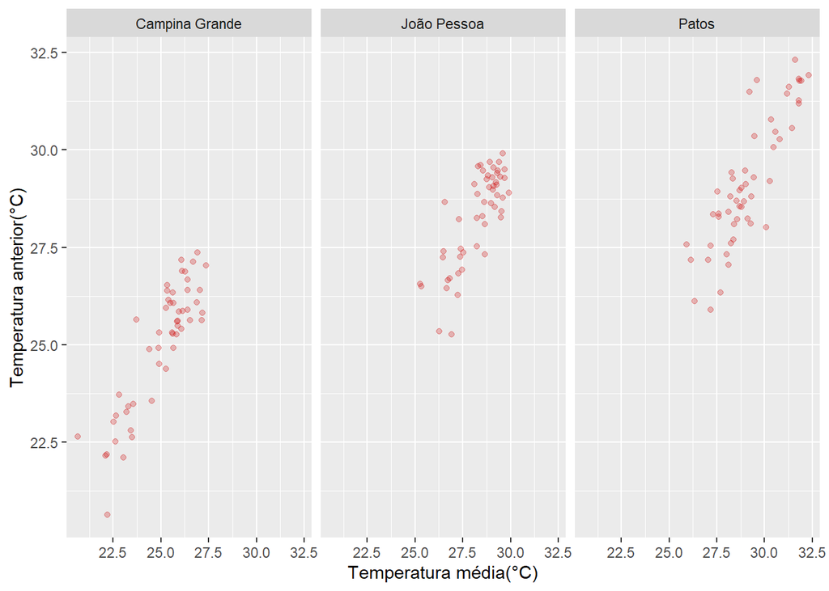

```r
temp_semanal2 %>%
    ggplot(aes(x = temp_media, y = temp_anterior)) +
    geom_point(alpha = .25, size = 1.5, colour="red3") +
    facet_wrap(~ cidade) +
    labs(
        x = "Temperatura média(°C)",
        y = "Temperatura anterior(°C)"
    )
```

**Semelhante à primeira avaliação da relação da temperatura semanal com a da semana anterior, a relação da temperatura de uma semana com a das 52 semanas que a antecederam apresenta um padrão linear positivo com alguns pontos extremos com uma variação de temperatura maior em Campina Grande e Patos, enquanto João Pessoa tem seus valores mais concentrados.**

```r
temp_semanal2 %>%
   group_by(cidade) %>%
   summarise(correlacao = cor(temp_media, temp_anterior,
                              method = "pearson"),
              .groups = "drop")
```

```
## # A tibble: 3 x 2
##   cidade         correlacao
##   <chr>               <dbl>
## 1 Campina Grande      0.884
## 2 João Pessoa         0.797
## 3 Patos               0.862
```

**É possível observar que existe, de fato, uma correlação positiva e de alta intensidade entre as temperaturas da semana escolhida e as 52 que a antecederam, sendo esta correlação mais alta nas cidades de Patos e Campina Grande. Diferentemente da primeira análise em que Campina Grande apresentou a correlação mais alta e João Pessoa e Patos tiveram uma correlação mais baixa e semelhantes entre si.**

### Descrição da relação entre a chuva de uma semana e a chuva da semana anterior e sua comparação com a primeira análise(das temperaturas).

```r
clima1 = clima_tudo %>%
  mutate(chuva_anterior = lag(chuva, n = 1))

chuva1 = clima1 %>%
    filter(!is.na(chuva)) %>%
    filter(!is.na(chuva_anterior)) %>%
    select(chuva, chuva_anterior,semana, cidade)
```

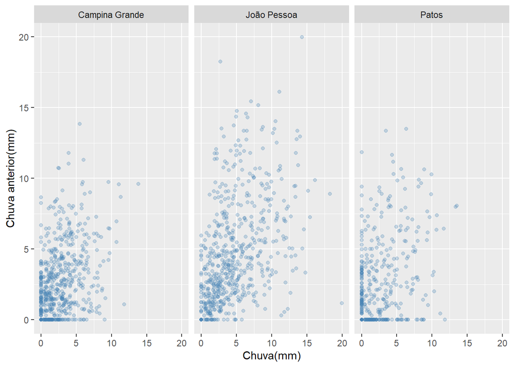

```r
chuva1 %>%
    mutate(chuva = sqrt(chuva)) %>%
    mutate(chuva_anterior = sqrt(chuva_anterior)) %>%
    ggplot(aes(x = chuva, y = chuva_anterior)) +
    geom_point(alpha = .27, size = 1.5,colour="steelblue") +
    facet_wrap(~ cidade) +
    labs(
        x = "Chuva(mm)",
        y = "Chuva anterior(mm)"
    )
```

**A relação das chuvas de uma semana com sua anterior apresenta um padrão quase linear positivo, porém com uma variação alta de valores e com muitos pontos extremos, porém com uma concentração maior em valores mais baixos.**

```r
chuva1 %>%
   group_by(cidade) %>%
   mutate(chuva = sqrt(chuva)) %>%
   mutate(chuva_anterior = sqrt(chuva_anterior)) %>%
   summarise(pearson_transformado = cor(chuva, chuva_anterior,
                                        method = "pearson"),
             spearman = cor(chuva, chuva_anterior,
                                        method = "spearman"),
              .groups = "drop")
```

```
## # A tibble: 3 x 3
##   cidade         pearson_transformado spearman
##   <chr>                         <dbl>    <dbl>
## 1 Campina Grande                0.379    0.393
## 2 João Pessoa                   0.436    0.496
## 3 Patos                         0.490    0.548
```

**Ao analisar os coeficientes de correlação das chuvas, nota-se que existe uma correlação pouco intensa entre elas, com a mais alta sendo em Patos. Em comparação com a correlação das temperaturas, as chuvas apresentam uma intensidade de correlação bem menor nas três cidades.**